### **Introdução**

Este projeto visa prever os custos médicos de pacientes usando o dataset **Healthcare Data** do Kaggle, criado por **Sahil Bajaj**, que contém informações sobre hospitalizações, exames médicos e histórico de saúde. A análise de dados médicos é essencial para prever custos e melhorar o planejamento orçamentário em hospitais e seguradoras. Aplicamos técnicas de pré-processamento e modelos de regressão para identificar os principais fatores que influenciam os custos médicos.

Os dados foram extraídos do dataset através do link https://www.kaggle.com/datasets/sahilnbajaj/healthcare-data.

# **Bibliotecas Utilizadas**

## **Bibliotecas de Manipulação e Análise de Dados**

- **`pandas`**: Manipulação de dados em formato tabular (DataFrames), essencial para a leitura, limpeza e transformação de dados.
- **`numpy`**: Manipulação de arrays e operações matemáticas eficientes, útil para operações numéricas e análise em grande escala.

## **Bibliotecas de Visualização**

- **`matplotlib.pyplot`**: Ferramenta fundamental para a criação de gráficos e visualizações, como gráficos de dispersão, barras e linhas.
- **`seaborn`**: Extensão do `matplotlib`, fornece uma interface de alto nível para criar gráficos estatísticos mais elegantes e complexos.

## **Biblioteca de Manipulação de Data e Hora**

- **`from datetime import datetime`**: Facilita a manipulação e análise de dados de data e hora, importante para calcular idades ou realizar operações com datas.

## **Bibliotecas de Pré-processamento e Avaliação**

- **`sklearn.preprocessing.LabelEncoder`**: Converte variáveis categóricas em formato numérico, facilitando o uso em modelos de aprendizado de máquina.
- **`sklearn.model_selection.train_test_split`**: Divide os dados em conjuntos de treinamento e teste, crucial para avaliar a generalização do modelo.
- **`sklearn.compose.ColumnTransformer`**: Aplica transformações específicas nas colunas de um DataFrame, como normalização e codificação.
- **`sklearn.preprocessing.StandardScaler`**: Normaliza as variáveis numéricas, ajustando para média zero e desvio padrão 1.
- **`sklearn.preprocessing.OneHotEncoder`**: Realiza a codificação de variáveis categóricas como variáveis binárias (one-hot encoding).
- **`sklearn.metrics.mean_squared_error`**: Calcula o erro quadrático médio (RMSE), utilizado para avaliar a precisão de modelos de regressão.
- **`sklearn.metrics.mean_absolute_error`**: Calcula o erro absoluto médio (MAE), importante para verificar a precisão dos modelos.
- **`sklearn.metrics.r2_score`**: Avalia a qualidade do ajuste do modelo de regressão, calculando o coeficiente de determinação (R²).

## **Bibliotecas de Modelagem**

- **`sklearn.pipeline.Pipeline`**: Facilita a criação de pipelines, permitindo agrupar transformações de dados e modelos em um único objeto.
- **Modelos de Regressão Linear**:
  - **`sklearn.linear_model.LinearRegression`**: Modelo de regressão linear simples para entender relações lineares entre variáveis.
  - **`sklearn.linear_model.BayesianRidge`**: Regressão bayesiana com regularização, ideal para dados com incerteza e variação.
  - **`sklearn.linear_model.ElasticNet`**: Combina regressões Lasso e Ridge, útil para problemas com multicolinearidade entre as variáveis.
  - **`sklearn.linear_model.HuberRegressor`**: Regressão robusta para minimizar a influência de outliers.
- **Modelos de Árvores e Conjuntos**:
  - **`sklearn.tree.DecisionTreeRegressor`**: Modelo de árvore de decisão para regressão, útil para aprender regras de decisão.
  - **`sklearn.ensemble.RandomForestRegressor`**: Conjunto de árvores de decisão, melhora a precisão e reduz o risco de overfitting.
  - **`sklearn.ensemble.GradientBoostingRegressor`**: Técnica de boosting, onde múltiplos modelos são treinados sequencialmente para corrigir erros.
- **Outros Modelos**:
  - **`sklearn.svm.SVR`**: Regressão com Máquinas de Vetores de Suporte, ideal para modelar relações não lineares.
  - **`sklearn.neighbors.KNeighborsRegressor`**: Regressão baseada nos k-vizinhos mais próximos, útil para dados agrupados por similaridade.
  - **`sklearn.neural_network.MLPRegressor`**: Modelo de regressão utilizando redes neurais (MLP), adequado para aprender relações complexas em grandes volumes de dados.

```python
## Bibliotecas de Manipulação e Análise de Dados
import pandas as pd
import numpy as np

## Bibliotecas de Visualização
import matplotlib.pyplot as plt
import seaborn as sns

## Biblioteca de Manipulação de Data e Hora
from datetime import datetime

## Bibliotecas de Pré-processamento e Avaliação
from sklearn.preprocessing import LabelEncoder
from sklearn.model_selection import train_test_split
from sklearn.compose import ColumnTransformer
from sklearn.preprocessing import StandardScaler, OneHotEncoder
from sklearn.metrics import mean_squared_error, mean_absolute_error, r2_score

## Bibliotecas de Modelagem
from sklearn.pipeline import Pipeline

# Modelos de Regressão Linear
from sklearn.linear_model import LinearRegression, BayesianRidge, ElasticNet, HuberRegressor

# Modelos de Árvores e Conjuntos
from sklearn.tree import DecisionTreeRegressor
from sklearn.ensemble import RandomForestRegressor, GradientBoostingRegressor

# Outros Modelos
from sklearn.svm import SVR
from sklearn.neighbors import KNeighborsRegressor
from sklearn.neural_network import MLPRegressor
```

### **# Carregar os arquivos CSV**

1. **`pd.read_csv()`**: Carrega os dados dos arquivos CSV sobre hospitalizações e exames médicos para DataFrames do pandas.
2. **`pd.read_excel()`**: Carrega o arquivo Excel contendo os nomes dos pacientes em um DataFrame.

### **Funcionamento**

O código carrega três conjuntos de dados de diferentes fontes (CSV e Excel) para análise.

### **Utilidade**

Esses dados são integrados para análise de informações sobre pacientes e suas hospitalizações e exames médicos.

```python
# Carregar os arquivos CSV
dados_hospitalisation = pd.read_csv("healthcare-data-Hospitalisation details.csv")
dados_medical = pd.read_csv("healthcare-data-Medical Examinations.csv")
dados_name = pd.read_excel("healthcare-data-Names.xlsx")
```

### **# Relacionar os DataFrames**

1. **`pd.merge(dados_medical, dados_hospitalisation, on="Customer ID", how="inner")`**: Relaciona os DataFrames `dados_medical` e `dados_hospitalisation` com base no "Customer ID", mantendo apenas as linhas com correspondência nos dois DataFrames.
2. **`pd.merge(dados_name, dados, on="Customer ID", how="inner")`**: Relaciona o DataFrame `dados_name` com o DataFrame resultante da primeira junção, também utilizando o "Customer ID" para mesclar os dados.

### **Funcionamento**

O código integra três DataFrames diferentes em um único, utilizando o "Customer ID" como chave de relacionamento para unir as informações sobre pacientes.

### **Utilidade**

Essa união é essencial para criar um conjunto de dados completo que contenha todas as informações dos pacientes, como exames médicos, hospitalizações e nomes, facilitando análises subsequentes.

```python
# Relacionar o dados_medical com dados_hospitalisation
dados = pd.merge(dados_medical, dados_hospitalisation, on="Customer ID", how="inner")

# Relacionar dados_name e o dados
dados = pd.merge(dados_name, dados, on="Customer ID", how="inner")

dados.head()
```

|  | Customer ID | name | BMI | HBA1C | Heart Issues | Any Transplants | Cancer history | NumberOfMajorSurgeries | smoker | year | month | date | children | charges | Hospital tier | City tier | State ID |
| --- | --- | --- | --- | --- | --- | --- | --- | --- | --- | --- | --- | --- | --- | --- | --- | --- | --- |
| 0 | Id1 | Hawks, Ms. Kelly | 47.410 | 7.47 | No | No | No | No major surgery | yes | 1968 | Oct | 12 | 0 | 63770.43 | tier - 1 | tier - 3 | R1013 |
| 1 | Id2 | Lehner, Mr. Matthew D | 30.360 | 5.77 | No | No | No | No major surgery | yes | 1977 | Jun | 8 | 0 | 62592.87 | tier - 2 | tier - 3 | R1013 |
| 2 | Id3 | Lu, Mr. Phil | 34.485 | 11.87 | yes | No | No | 2 | yes | 1970 | ? | 11 | 3 | 60021.40 | tier - 1 | tier - 1 | R1012 |
| 3 | Id4 | Osborne, Ms. Kelsey | 38.095 | 6.05 | No | No | No | No major surgery | yes | 1991 | Jun | 6 | 1 | 58571.07 | tier - 1 | tier - 3 | R1024 |
| 4 | Id5 | Kadala, Ms. Kristyn | 35.530 | 5.45 | No | No | No | No major surgery | yes | 1989 | Jun | 19 | 0 | 55135.40 | tier - 1 | tier - 2 | R1012 |

### **# Verificar informações iniciais do DataFrame**

1. **`print(dados.info())`**: Exibe informações gerais sobre o DataFrame `dados`, como número de entradas, tipos de dados das colunas e quantidade de valores não nulos em cada coluna.

### **# Remover linhas com valores nulos**

2. **`dados = dados.dropna()`**: Remove todas as linhas que contêm valores nulos (`NaN`) no DataFrame `dados`, garantindo que os dados estejam completos e prontos para análise.

### **Funcionamento**

O primeiro comando fornece uma visão geral da estrutura do DataFrame, enquanto o segundo garante que não haja valores ausentes nos dados, um passo importante para evitar erros durante a modelagem de dados.

### **Utilidade**

Esses comandos ajudam a verificar a integridade dos dados e preparar o conjunto para análise, removendo registros incompletos que poderiam prejudicar a performance dos modelos de aprendizado de máquina.

```python
# Verificar informações iniciais do DataFrame
print(dados.info())

# Remover linhas com valores nulos
dados = dados.dropna()
```

```
<class 'pandas.core.frame.DataFrame'>
RangeIndex: 2335 entries, 0 to 2334
Data columns (total 17 columns):
 #   Column                  Non-Null Count  Dtype
---  ------                  --------------  -----
 0   Customer ID             2335 non-null   object
 1   name                    2335 non-null   object
 2   BMI                     2335 non-null   float64
 3   HBA1C                   2335 non-null   float64
 4   Heart Issues            2335 non-null   object
 5   Any Transplants         2335 non-null   object
 6   Cancer history          2335 non-null   object
 7   NumberOfMajorSurgeries  2335 non-null   object
 8   smoker                  2335 non-null   object
 9   year                    2335 non-null   object
 10  month                   2335 non-null   object
 11  date                    2335 non-null   int64
 12  children                2335 non-null   int64
 13  charges                 2335 non-null   float64
 14  Hospital tier           2335 non-null   object
 15  City tier               2335 non-null   object
 16  State ID                2335 non-null   object
dtypes: float64(3), int64(2), object(12)
memory usage: 310.2+ KB
None
```

### **# Verificar se possui Customer ID duplicado**

Verifica se há registros com IDs de cliente duplicados no DataFrame.

### **# Exibir valores distintos nas colunas do DataFrame**

Exibe os valores únicos em várias colunas do DataFrame, permitindo verificar a diversidade dos dados.

### **Funcionamento**

Esses comandos ajudam a identificar dados inconsistentes ou variáveis com valores repetidos ou inesperados.

### **Utilidade**

Essas verificações garantem a integridade dos dados antes de realizar a análise ou modelagem, evitando problemas causados por duplicatas ou valores inválidos.

```python
# Verificar se possui Customer Id duplicado
print(F"Possui algum Customer ID duplicado?: {dados['Customer ID'].duplicated().any()}")

# Exibe valores distintos nas colunas do DataFrame
print(f"Valores distintos na coluna 'Heart Issues': {dados['Heart Issues'].unique()}")
print(f"Valores distintos na coluna 'Any Transplants': {dados['Any Transplants'].unique()}")
print(f"Valores distintos na coluna 'Cancer history': {dados['Cancer history'].unique()}")
print(f"Valores distintos na coluna 'NumberOfMajorSurgeries': {dados['NumberOfMajorSurgeries'].unique()}")
print(f"Valores distintos na coluna 'smoker': {dados['smoker'].unique()}")
print(f"Valores distintos na coluna 'year': {dados['year'].unique()}")
print(f"Valores distintos na coluna 'month': {dados['month'].unique()}")
print(f"Valores distintos na coluna 'Hospital tier': {dados['Hospital tier'].unique()}")
print(f"Valores distintos na coluna 'City tier': {dados['City tier'].unique()}")
print(f"Valores distintos na coluna 'State ID': {dados['State ID'].unique()}")
```

```
Possui algum Customer ID duplicado?: False
Valores distintos na coluna 'Heart Issues': ['No' 'yes']
Valores distintos na coluna 'Any Transplants': ['No' 'yes']
Valores distintos na coluna 'Cancer history': ['No' 'Yes']
Valores distintos na coluna 'NumberOfMajorSurgeries': ['No major surgery' '2' '3' '1']
Valores distintos na coluna 'smoker': ['yes' 'No' '?']
Valores distintos na coluna 'year': ['1968' '1977' '1970' '1991' '1989' '1962' '1994' '1958' '1963' '1978'
 '1959' '1965' '1961' '1964' '1971' '1960' '1969' '1976' '1985' '1979'
 '1974' '1993' '2000' '1967' '1975' '1988' '1966' '1980' '1986' '1972'
 '1973' '1997' '1984' '1983' '1992' '1999' '1981' '1982' '1987' '2003'
 '1995' '2004' '1990' '2002' '1998' '1996' '2001' '?']
Valores distintos na coluna 'month': ['Oct' 'Jun' '?' 'Aug' 'Sep' 'Dec' 'Jul' 'Nov']
Valores distintos na coluna 'Hospital tier': ['tier - 1' 'tier - 2' 'tier - 3' '?']
Valores distintos na coluna 'City tier': ['tier - 3' 'tier - 1' 'tier - 2' '?']
Valores distintos na coluna 'State ID': ['R1013' 'R1012' 'R1024' 'R1011' 'R1016' 'R1015' 'R1017' 'R1014' 'R1023'
 'R1019' '?' 'R1018' 'R1026' 'R1022' 'R1021' 'R1025' 'R1020']
```

### **# Contar ocorrências com a string "?" nas colunas**

Conta quantas vezes a string "?" aparece em várias colunas do DataFrame, ajudando a identificar dados ausentes ou inválidos.

### **Funcionamento**

Esses comandos utilizam a função `apply()` para verificar cada valor nas colunas especificadas e contar quantas vezes a string "?" aparece.

### **Utilidade**

Essa verificação é útil para identificar onde há dados ausentes ou problemas de formatação, permitindo o tratamento adequado desses casos antes de aplicar modelos ou análises.

```python
# Conta a quantidade de ocorrências com a string "?" nas colunas
print(f"A coluna 'Hospital tier' possui {dados['Hospital tier'].apply(lambda x: x == '?').sum()} ocorrências com a string '?'.")
print(f"A coluna 'City tier' possui {dados['City tier'].apply(lambda x: x == '?').sum()} ocorrências com a string '?'.")
print(f"A coluna 'smoker' possui {dados['smoker'].apply(lambda x: x == '?').sum()} ocorrências com a string '?'.")
print(f"A coluna 'year' possui {dados['year'].apply(lambda x: x == '?').sum()} ocorrências com a string '?'.")
print(f"A coluna 'month' possui {dados['month'].apply(lambda x: x == '?').sum()} ocorrências com a string '?'.")
print(f"A coluna 'State ID' possui {dados['State ID'].apply(lambda x: x == '?').sum()} ocorrências com a string '?'.")
```

```
A coluna 'Hospital tier' possui 1 ocorrências com a string '?'.
A coluna 'City tier' possui 1 ocorrências com a string '?'.
A coluna 'smoker' possui 2 ocorrências com a string '?'.
A coluna 'year' possui 2 ocorrências com a string '?'.
A coluna 'month' possui 3 ocorrências com a string '?'.
A coluna 'State ID' possui 2 ocorrências com a string '?'.
```

### **# Transformar "No major surgery" em 0 e converter o restante para números**

Substitui a string "No major surgery" por 0 na coluna **`NumberOfMajorSurgeries`** e converte todos os valores restantes para numéricos, tratando dados de maneira adequada para análise.

### **# Remover linhas onde valores inválidos estejam presentes**

Filtra o DataFrame para remover as linhas que contêm valores inválidos representados pela string `"?"` nas colunas **`Hospital tier`**, **`City tier`**, **`smoker`**, **`year`**, **`month`**, e **`State ID`**.

### **Funcionamento**

Esses comandos preparam os dados, transformando informações não numéricas em valores numéricos válidos e removendo registros incompletos, garantindo que o DataFrame esteja pronto para modelagem e análise.

### **Utilidade**

Esses passos são essenciais para limpar e formatar os dados antes de alimentar os modelos de aprendizado de máquina, evitando problemas de inconsistência e dados ausentes.

```python
# Transformar "No major surgery" em 0 e converter o restante para números
dados["NumberOfMajorSurgeries"] = dados["NumberOfMajorSurgeries"].replace("No major surgery", 0)
dados["NumberOfMajorSurgeries"] = pd.to_numeric(dados["NumberOfMajorSurgeries"], errors="coerce")

# Remover linhas onde valores inválidos estejam presentes
dados = dados[
    (dados["Hospital tier"] != "?") &
    (dados["City tier"] != "?") &
    (dados["smoker"] != "?") &
    (dados["year"] != "?") &
    (dados["month"] != "?") &
    (dados["State ID"] != "?")
]
```

### **# Função para Extrair Gênero a partir do Nome**

1. **`def extract_gender(name)`**: Define uma função que identifica o gênero com base nos títulos de cortesia ("Mr.", "Ms.", "Mrs.") no nome.
2. **`dados['gender'] = dados['name'].apply(extract_gender)`**: Cria uma nova coluna **`gender`** com o gênero extraído de cada nome utilizando a função definida.
3. **`dados = dados.drop(columns=['name'])`**: Remove a coluna **`name`** após a extração do gênero, para manter apenas as informações relevantes.

### **Funcionamento**

A função extrai o gênero dos nomes com base nos títulos de cortesia, criando uma coluna de gênero e removendo a coluna de nome.

### **Utilidade**

Facilita a análise dos dados ao estruturar o gênero de forma numérica e eliminar dados irrelevantes, melhorando a clareza do DataFrame.

```python
# Função para Extrair Gênero a partir do Nome
def extract_gender(name):
    if 'Mr.' in name:
        return 'Male'
    elif 'Ms.' in name or 'Mrs.' in name:
        return 'Female'
    else:
        return 'Unknown'

dados['gender'] = dados['name'].apply(extract_gender)
dados = dados.drop(columns=['name'])
```

### **# Transformação com LabelEncoder**

- **Transformação com `LabelEncoder`**:
  - O código utiliza o **`LabelEncoder`** da biblioteca `sklearn` para transformar variáveis categóricas em valores numéricos.
  - Para cada coluna na lista **`colunas_transformar`**, o **`LabelEncoder`** é aplicado, atribuindo um número inteiro a cada categoria única na coluna.

### **Funcionamento**

- **`colunas_transformar`**: Define uma lista com os nomes das colunas que contêm variáveis categóricas a serem transformadas (ex: "Heart Issues", "smoker", "City tier").
- **`le.fit_transform(dados[coluna])`**: Para cada coluna, o `LabelEncoder` mapeia os valores categóricos para números, armazenando os resultados na própria coluna.

### **Utilidade**

Esse processo é necessário para preparar os dados categóricos para modelos de aprendizado de máquina, que geralmente exigem que todas as variáveis sejam numéricas.

```python
# Transformação com LabelEncoder
colunas_transformar = [
    "Heart Issues",
    "Any Transplants",
    "Cancer history",
    "smoker",
    "Hospital tier",
    "City tier",
    "gender"
]

for coluna in colunas_transformar:
    le = LabelEncoder()
    dados[coluna] = le.fit_transform(dados[coluna])
```

### **# Garantir que o tipo seja int64**

1. **Garantir que o tipo seja `int64`**:
   - **`dados[colunas_transformar] = dados[colunas_transformar].astype("int64")`**:
     - Converte as colunas especificadas em **`colunas_transformar`** para o tipo de dado `int64`, assegurando que os valores nessas colunas sejam inteiros de 64 bits.

### **# Verificar o resultado**

1. **Verificar o resultado**:
   - **`print(dados.head())`**:
     - Exibe as primeiras 5 linhas do DataFrame **`dados`** após a conversão, permitindo verificar se a transformação foi aplicada corretamente.

### **Funcionamento**

- O código converte as colunas de variáveis categóricas para o tipo **`int64`**, garantindo que os dados estejam no formato adequado para a análise ou modelos de aprendizado de máquina.
- O comando **`print(dados.head())`** exibe uma amostra dos dados transformados para garantir que a conversão foi bem-sucedida.

### **Utilidade**

Esses passos são importantes para garantir que as variáveis categóricas transformadas com o `LabelEncoder` estejam no formato correto (inteiro) antes de serem usadas em modelos de aprendizado de máquina.

```python
# Garantir que o tipo seja int64
dados[colunas_transformar] = dados[colunas_transformar].astype("int64")

# Verificar o resultado
dados.head()
```

|  | Customer ID | BMI | HBA1C | Heart Issues | Any Transplants | Cancer history | NumberOfMajorSurgeries | smoker | year | month | date | children | charges | Hospital tier | City tier | State ID | gender |
| --- | --- | --- | --- | --- | --- | --- | --- | --- | --- | --- | --- | --- | --- | --- | --- | --- | --- |
| 0 | Id1 | 47.410 | 7.47 | 0 | 0 | 0 | 0 | 1 | 1968 | Oct | 12 | 0 | 63770.43 | 0 | 2 | R1013 | 0 |
| 1 | Id2 | 30.360 | 5.77 | 0 | 0 | 0 | 0 | 1 | 1977 | Jun | 8 | 0 | 62592.87 | 1 | 2 | R1013 | 1 |
| 3 | Id4 | 38.095 | 6.05 | 0 | 0 | 0 | 0 | 1 | 1991 | Jun | 6 | 1 | 58571.07 | 0 | 2 | R1024 | 0 |
| 4 | Id5 | 35.530 | 5.45 | 0 | 0 | 0 | 0 | 1 | 1989 | Jun | 19 | 0 | 55135.40 | 0 | 1 | R1012 | 0 |
| 5 | Id6 | 32.800 | 6.59 | 0 | 0 | 0 | 0 | 1 | 1962 | Aug | 4 | 0 | 52590.83 | 0 | 2 | R1011 | 1 |

### **# Converter meses de string para números**

1. **`meses_dict = {...}`**: Um dicionário que mapeia os meses em formato de string (por exemplo, 'Oct', 'Jun') para números correspondentes (por exemplo, 10 para 'Oct', 6 para 'Jun').
2. **`dados['month_num'] = dados['month'].map(meses_dict)`**: A função **`map()`** é utilizada para aplicar o mapeamento do dicionário **`meses_dict`** à coluna **`month`** do DataFrame **`dados`**. O resultado é uma nova coluna chamada **`month_num`**, que contém os números dos meses correspondentes.
3. **`dados.head()`**: Exibe as primeiras linhas do DataFrame **`dados`** para verificar se a conversão foi realizada corretamente, mostrando a nova coluna **`month_num`**.

### **Funcionamento**

Esse código transforma os meses, originalmente representados como strings, em valores numéricos correspondentes a cada mês do ano, facilitando o uso desses dados em modelos preditivos.

### **Utilidade**

Ao transformar os meses em números, o modelo pode lidar com os dados de maneira mais eficiente, já que muitos algoritmos de aprendizado de máquina exigem variáveis numéricas para processar informações.

```python
# Converter meses de string para números
meses_dict = {
    'Oct': 10, 'Jun': 6, 'Aug': 8, 'Sep': 9, 'Dec': 12, 'Jul': 7, 'Nov': 11
}
dados['month_num'] = dados['month'].map(meses_dict)

dados.head()
```

|  | Customer ID | BMI | HBA1C | Heart Issues | Any Transplants | Cancer history | NumberOfMajorSurgeries | smoker | year | month | date | children | charges | Hospital tier | City tier | State ID | gender | month_num |
| --- | --- | --- | --- | --- | --- | --- | --- | --- | --- | --- | --- | --- | --- | --- | --- | --- | --- | --- |
| 0 | Id1 | 47.410 | 7.47 | 0 | 0 | 0 | 0 | 1 | 1968 | Oct | 12 | 0 | 63770.43 | 0 | 2 | R1013 | 0 | 10 |
| 1 | Id2 | 30.360 | 5.77 | 0 | 0 | 0 | 0 | 1 | 1977 | Jun | 8 | 0 | 62592.87 | 1 | 2 | R1013 | 1 | 6 |
| 3 | Id4 | 38.095 | 6.05 | 0 | 0 | 0 | 0 | 1 | 1991 | Jun | 6 | 1 | 58571.07 | 0 | 2 | R1024 | 0 | 6 |
| 4 | Id5 | 35.530 | 5.45 | 0 | 0 | 0 | 0 | 1 | 1989 | Jun | 19 | 0 | 55135.40 | 0 | 1 | R1012 | 0 | 6 |
| 5 | Id6 | 32.800 | 6.59 | 0 | 0 | 0 | 0 | 1 | 1962 | Aug | 4 | 0 | 52590.83 | 0 | 2 | R1011 | 1 | 8 |

### **# Lista as informações atualizadas do DataFrame**

O comando `dados.info()` exibe um resumo das informações do DataFrame `dados`, incluindo:

1. **Número de entradas (linhas)**: Exibe o total de linhas (entradas) no DataFrame.
2. **Nome e tipo das colunas**: Mostra os nomes de todas as colunas e os tipos de dados associados a elas.
3. **Valores não nulos**: Exibe a quantidade de valores não nulos para cada coluna, ajudando a identificar a presença de dados ausentes.
4. **Uso de memória**: Fornece informações sobre o quanto de memória o DataFrame está consumindo.

Esse comando é útil para verificar a estrutura do conjunto de dados e identificar potenciais problemas, como valores ausentes ou tipos de dados inconsistentes.

```python
# Lista as informações atualizadas do DataFrame
dados.info()
```

```
<class 'pandas.core.frame.DataFrame'>
Index: 2325 entries, 0 to 2334
Data columns (total 18 columns):
 #   Column                  Non-Null Count  Dtype
---  ------                  --------------  -----
 0   Customer ID             2325 non-null   object
 1   BMI                     2325 non-null   float64
 2   HBA1C                   2325 non-null   float64
 3   Heart Issues            2325 non-null   int64
 4   Any Transplants         2325 non-null   int64
 5   Cancer history          2325 non-null   int64
 6   NumberOfMajorSurgeries  2325 non-null   int64
 7   smoker                  2325 non-null   int64
 8   year                    2325 non-null   object
 9   month                   2325 non-null   object
 10  date                    2325 non-null   int64
 11  children                2325 non-null   int64
 12  charges                 2325 non-null   float64
 13  Hospital tier           2325 non-null   int64
 14  City tier               2325 non-null   int64
 15  State ID                2325 non-null   object
 16  gender                  2325 non-null   int64
 17  month_num               2325 non-null   int64
dtypes: float64(3), int64(11), object(4)
memory usage: 345.1+ KB
```

### **Concatenar as colunas `year`, `month` e `date` para calcular a idade**

1. **`dados["Data_Concatenada"] = dados["year"].astype(str) + "-" + dados["month"] + "-" + dados["date"].astype(str)`**:
   - Cria uma nova coluna **`Data_Concatenada`** ao concatenar as colunas `year`, `month` e `date` em um formato de string de data.
2. **`dados['Data_Concatenada'] = pd.to_datetime(dados['Data_Concatenada'], format='%Y-%b-%d')`**:
   - Converte a coluna **`Data_Concatenada`** para o tipo `datetime` no formato específico de ano, mês (abreviado) e dia, permitindo manipulação de datas.
3. **`dados['age'] = (datetime.now() - dados['Data_Concatenada']).dt.days / 365.25`**:
   - Calcula a idade dos pacientes em anos, subtraindo a data de nascimento (**`Data_Concatenada`**) da data atual e convertendo os dias para anos.
4. **`dados['age'] = dados['age'].astype(int)`**:
   - Converte os valores calculados para idade para o tipo inteiro.
5. **`dados = dados.drop(columns=['year', 'month', 'month_num', 'date', 'Data_Concatenada'])`**:
   - Remove as colunas **`year`, `month`, `month_num`, `date`** e **`Data_Concatenada**, pois já não são mais necessárias após o cálculo da idade.

### **Funcionamento**

Este código cria uma nova coluna de idade a partir das colunas de data (ano, mês e dia), converte para o tipo adequado e limpa as colunas originais desnecessárias.

### **Utilidade**

A operação é essencial para calcular a idade a partir de informações de data e transformar os dados em um formato útil para análises ou modelos preditivos.

```python
# Concatenar as colunas year, month e date
dados["Data_Concatenada"] = dados["year"].astype(str) + "-" + dados["month"] + "-" + dados["date"].astype(str)
dados['Data_Concatenada']

# Converter 'Data_Concatenada' para o tipo datetime
dados['Data_Concatenada'] = pd.to_datetime(dados['Data_Concatenada'], format='%Y-%b-%d')

# Calcular a idade em anos
dados['age'] = (datetime.now() - dados['Data_Concatenada']).dt.days / 365.25

# Converter para inteiro
dados['age'] = dados['age'].astype(int)

# Remove as colunas que não serão mais utiizadas
dados = dados.drop(columns=['year', 'month', 'month_num', 'date', 'Data_Concatenada'])
```

### **# Lista as informações atualizadas do DataFrame**

O comando `dados.info()` exibe um resumo das informações do DataFrame `dados`, incluindo:

1. **Número de entradas (linhas)**: Exibe o total de linhas (entradas) no DataFrame.
2. **Nome e tipo das colunas**: Mostra os nomes de todas as colunas e os tipos de dados associados a elas.
3. **Valores não nulos**: Exibe a quantidade de valores não nulos para cada coluna, ajudando a identificar a presença de dados ausentes.
4. **Uso de memória**: Fornece informações sobre o quanto de memória o DataFrame está consumindo.

Esse comando é útil para verificar a estrutura do conjunto de dados e identificar potenciais problemas, como valores ausentes ou tipos de dados inconsistentes.

```python
# Lista as informações atualizadas do DataFrame
dados.info()
```

```
<class 'pandas.core.frame.DataFrame'>
Index: 2325 entries, 0 to 2334
Data columns (total 15 columns):
 #   Column                  Non-Null Count  Dtype
---  ------                  --------------  -----
 0   Customer ID             2325 non-null   object
 1   BMI                     2325 non-null   float64
 2   HBA1C                   2325 non-null   float64
 3   Heart Issues            2325 non-null   int64
 4   Any Transplants         2325 non-null   int64
 5   Cancer history          2325 non-null   int64
 6   NumberOfMajorSurgeries  2325 non-null   int64
 7   smoker                  2325 non-null   int64
 8   children                2325 non-null   int64
 9   charges                 2325 non-null   float64
 10  Hospital tier           2325 non-null   int64
 11  City tier               2325 non-null   int64
 12  State ID                2325 non-null   object
 13  gender                  2325 non-null   int64
 14  age                     2325 non-null   int64
dtypes: float64(3), int64(10), object(2)
memory usage: 290.6+ KB
```

### **Gerar um Mapa de Calor de Correlação**

1. **`plt.figure(figsize=(10,10))`**:
   - Define o tamanho da figura do gráfico de calor, especificando uma dimensão quadrada de 10x10.
2. **`sns.heatmap(dados.corr(numeric_only=True), annot=True, cmap='Greens')`**:
   - Cria um mapa de calor para exibir as correlações entre as variáveis numéricas do DataFrame **`dados`**.
   - **`dados.corr(numeric_only=True)`**: Calcula a matriz de correlação entre as colunas numéricas.
   - **`annot=True`**: Exibe os valores de correlação diretamente no gráfico.
   - **`cmap='Greens'`**: Define o esquema de cores do gráfico para uma paleta de verdes.

### **Funcionamento**

O código exibe um gráfico de calor (heatmap) que mostra a correlação entre variáveis numéricas, com os valores numéricos anotados no gráfico e um esquema de cores verde.

### **Utilidade**

O mapa de calor é útil para visualizar a força da correlação entre variáveis, permitindo identificar rapidamente quais variáveis estão mais ou menos relacionadas entre si.

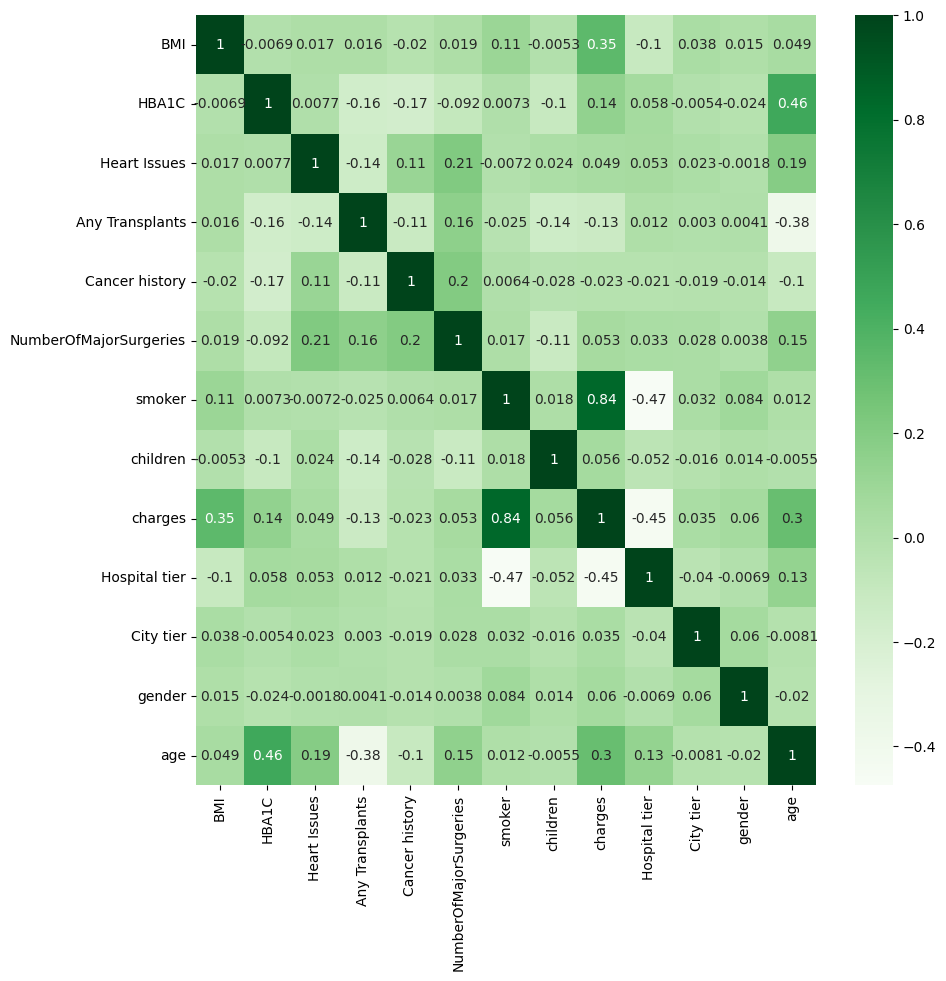

```python
plt.figure(figsize=(10,10))
sns.heatmap(dados.corr(numeric_only=True), annot=True, cmap='Greens')
```

### **# Corte das Colunas**

A decisão de cortar as colunas **`HBA1C`, `Heart Issues`, `Any Transplants`, `Cancer history`, `NumberOfMajorSurgeries`, `children`, `City tier`, `gender`, `Customer ID`** e **`State ID`** foi tomada com base na análise de correlação e relevância preditiva dos dados.

#### **1. Baixa correlação com "charges"**

- Colunas como **`HBA1C`, `Heart Issues`, `Any Transplants`, `Cancer history`, `NumberOfMajorSurgeries`** apresentaram baixa correlação com a variável alvo ("charges"). Isso indicou que essas variáveis não agregam informação significativa para prever os custos médicos, o que justificou a remoção delas.

#### **2. Colunas redundantes ou irrelevantes**

- As variáveis **`children`, `City tier`, `gender`, `Customer ID`, `State ID`** também foram descartadas, uma vez que apresentaram uma correlação fraca ou nenhuma com a variável de interesse e poderiam criar redundância nos dados. Por exemplo, **`gender`** e **`City tier`** não foram fortes preditores para os custos médicos.

#### **Objetivo do corte:**

- O corte dessas colunas visa otimizar o modelo de previsão dos custos médicos, mantendo apenas as variáveis mais relevantes e evitando o risco de overfitting (quando o modelo aprende "demais" com variáveis irrelevantes, prejudicando sua generalização).

```python
# Corte das Colunas
dados = dados.drop(columns=['HBA1C', 'Heart Issues','Any Transplants','Cancer history','NumberOfMajorSurgeries', 'children','City tier', 'gender', 'Customer ID', 'State ID'])
```

### **# Resumo estatístico das colunas numéricas**

O comando `dados.describe()` fornece um resumo estatístico das colunas numéricas do DataFrame, incluindo medidas como média, desvio padrão, quartis e valores máximo e mínimo.

```python
# Resumo estatístico das colunas numéricas
dados.describe()
```

|  | BMI | smoker | charges | Hospital tier | age |
| --- | --- | --- | --- | --- | --- |
| count | 2325.000000 | 2325.000000 | 2325.000000 | 2325.000000 | 2325.000000 |
| mean | 30.995630 | 0.209032 | 13521.660254 | 1.168172 | 41.243011 |
| std | 8.744938 | 0.406705 | 11863.492697 | 0.630972 | 13.371684 |
| min | 15.010000 | 0.000000 | 563.840000 | 0.000000 | 20.000000 |
| 25% | 24.605000 | 0.000000 | 5116.500000 | 1.000000 | 30.000000 |
| 50% | 30.400000 | 0.000000 | 9634.540000 | 1.000000 | 41.000000 |
| 75% | 36.300000 | 0.000000 | 16903.500000 | 2.000000 | 53.000000 |
| max | 55.050000 | 1.000000 | 63770.430000 | 2.000000 | 66.000000 |

### **# Define Plotar Distribuições**

1. **Função `plot_histogram`**:
   - Define uma função **`plot_histogram`** que cria um gráfico de histograma com a opção de exibir uma curva de densidade (KDE).
   - **Parâmetros**:
     - **`coluna`**: Nome da coluna do DataFrame a ser plotada.
     - **`titulo`**: Título do gráfico.
     - **`cor`**: Cor do histograma.
   - Dentro da função, a biblioteca `seaborn` é usada para gerar o histograma, e a biblioteca `matplotlib` para configurar o gráfico (tamanho, rótulos e exibição).

### **Funcionamento**

- O código cria um gráfico de histograma para cada uma das colunas especificadas, exibindo a distribuição dos dados e uma curva de densidade (KDE), o que ajuda a visualizar a distribuição e a dispersão dos dados.

### **Utilidade**

A plotagem das distribuições é importante para analisar a forma e a dispersão dos dados, o que pode fornecer insights sobre a normalidade dos dados, a presença de outliers e ajudar na escolha de modelos adequados.

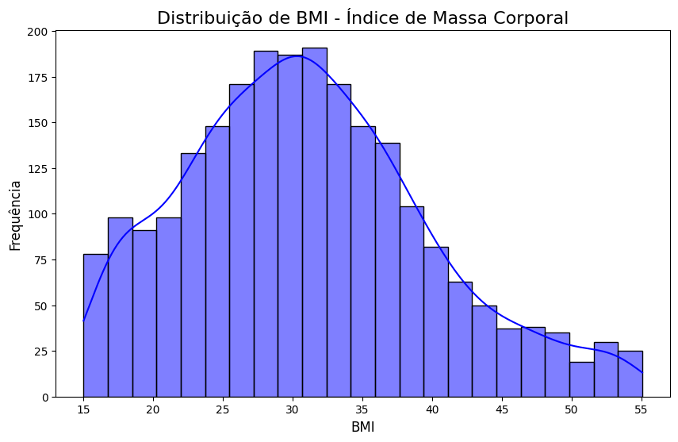

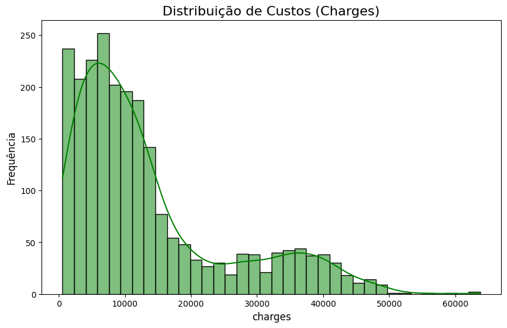

```python
# Define Plotar Distribuições
def plot_histogram(coluna, titulo, cor):
    plt.figure(figsize=(10, 6))
    sns.histplot(dados[coluna], kde=True, color=cor)
    plt.title(titulo, fontsize=16)
    plt.xlabel(coluna, fontsize=12)
    plt.ylabel("Frequência", fontsize=12)
    plt.show()

# Plotar distribuições
plot_histogram("BMI", "Distribuição de BMI - Índice de Massa Corporal", "blue")
plot_histogram("charges", "Distribuição de Custos (Charges)", "green")
```

### **# Plotar Distribuições de Variáveis Categóricas**

1. **Função `plot_categorical`**:
   - Define uma função **`plot_categorical`** para criar gráficos de barras (usando **`sns.countplot`**) para variáveis categóricas.
   - **Parâmetros**:
     - **`coluna`**: Nome da coluna categórica a ser plotada.
     - **`titulo`**: Título do gráfico.
     - **`paleta`**: Paleta de cores a ser utilizada no gráfico.
   - Dentro da função, é configurado o gráfico com `matplotlib` (tamanho, rótulos e exibição).

### **# Plotar variáveis categóricas**

1. **Plotar Variáveis Categóricas**:
   - A função **`plot_categorical`** é chamada para plotar as distribuições de várias colunas categóricas, com as cores definidas:
     - **"smoker"**: Fumantes (paleta: "muted").
     - **"Hospital tier"**: Camada hospitalar (paleta: "coolwarm").

### **Funcionamento**

- O código gera gráficos de barras para cada variável categórica, exibindo a frequência de cada categoria. Isso ajuda a visualizar a distribuição das categorias em cada coluna e verificar o equilíbrio ou a predominância de certos valores.

### **Utilidade**

Esses gráficos são úteis para entender a distribuição de variáveis qualitativas no dataset, o que pode influenciar a escolha de pré-processamento e modelos adequados.

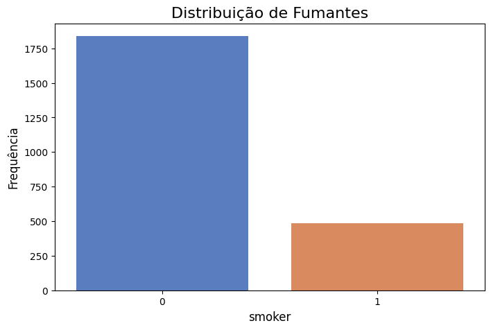

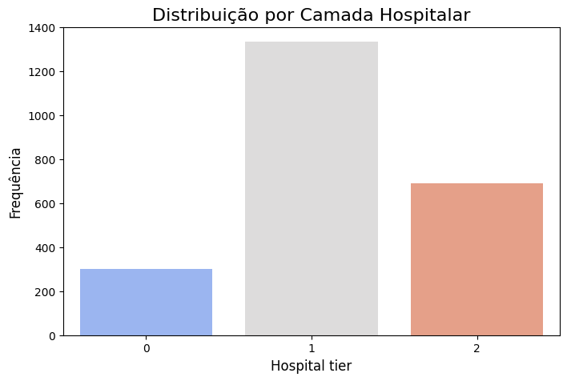

```python
# Plotar Distribuições de Variáveis Categóricas
def plot_categorical(coluna, titulo, paleta):
    plt.figure(figsize=(8, 5))
    sns.countplot(x=coluna, data=dados, palette=paleta)
    plt.title(titulo, fontsize=16)
    plt.xlabel(coluna, fontsize=12)
    plt.ylabel("Frequência", fontsize=12)
    plt.show()

# Plotar variáveis categóricas
# plot_categorical("children", "Distribuição de Número de Crianças", "pastel")
plot_categorical("smoker", "Distribuição de Fumantes", "muted")
# plot_categorical("Heart Issues", "Distribuição de Problemas Cardíacos", "Set2")
# plot_categorical("Cancer history", "Distribuição de Histórico de Câncer", "muted")
# plot_categorical("Any Transplants", "Distribuição de Transplantes", "pastel")
# plot_categorical("NumberOfMajorSurgeries", "Distribuição de Cirurgias Maiores", "Set2")
plot_categorical("Hospital tier", "Distribuição por Camada Hospitalar", "coolwarm")
# plot_categorical("City tier", "Distribuição por Camada da Cidade", "cubehelix")
```

### **# Verificar tipos de dados**

1. **Verificar Tipos de Dados**:
   - **`print(dados.dtypes)`**:
     - Exibe o tipo de dados de cada coluna do DataFrame **`dados`**, ajudando a identificar se as colunas possuem o tipo adequado (por exemplo, numérico, categórico, etc.).

### **# Verificar intervalos de valores em colunas numéricas**

1. **Verificar Intervalos de Valores nas Colunas Numéricas**:
   - **`colunas_numericas = dados.select_dtypes(include=["int64", "float64"]).columns`**:
     - Seleciona as colunas numéricas (tipos **`int64`** e **`float64`**) do DataFrame **`dados`**.
   - **`print(dados[colunas_numericas].describe())`**:
     - Exibe um resumo estatístico (como média, desvio padrão, valor mínimo, máximo e quartis) das colunas numéricas, fornecendo uma visão geral dos valores e distribuição.

### **Funcionamento**

- O primeiro comando exibe os tipos de dados de todas as colunas, enquanto o segundo fornece um resumo das variáveis numéricas, destacando suas principais características.

### **Utilidade**

Esses comandos são essenciais para uma análise exploratória inicial dos dados, garantindo que os tipos de dados estejam corretos e permitindo uma visão estatística das variáveis numéricas.

```python
# Verificar tipos de dados
print("Tipos de dados por coluna:")
print(dados.dtypes)

# Verificar intervalos de valores em colunas numéricas
colunas_numericas = dados.select_dtypes(include=["int64", "float64"]).columns
print("Resumo estatístico de colunas numéricas:")
print(dados[colunas_numericas].describe())
```

```
Tipos de dados por coluna:
BMI              float64
smoker             int64
charges          float64
Hospital tier      int64
age                int64
dtype: object
Resumo estatístico de colunas numéricas:
               BMI       smoker       charges  Hospital tier          age
count  2325.000000  2325.000000   2325.000000    2325.000000  2325.000000
mean     30.995630     0.209032  13521.660254       1.168172    41.243011
std       8.744938     0.406705  11863.492697       0.630972    13.371684
min      15.010000     0.000000    563.840000       0.000000    20.000000
25%      24.605000     0.000000   5116.500000       1.000000    30.000000
50%      30.400000     0.000000   9634.540000       1.000000    41.000000
75%      36.300000     0.000000  16903.500000       2.000000    53.000000
max      55.050000     1.000000  63770.430000       2.000000    66.000000
```

### **Funcionamento**

- A função verifica, para cada coluna, se existem valores negativos. Se algum valor negativo for encontrado, é exibida uma mensagem de alerta. Caso contrário, a função informa que todos os valores estão dentro do padrão.

### **Utilidade**

Esse processo é útil para detectar problemas nos dados, como a presença de valores negativos que podem ser inválidos ou fora do esperado, antes de realizar a análise ou treinamento de modelos.

```python
# Checar possíveis problemas em colunas específicas
def verificar_coluna_negativa(coluna):
    if (dados[coluna] < 0).any():
        print(f"Atenção: Há valores negativos na coluna {coluna}.")
    else:
        print(f"{coluna}: Todos os valores estão dentro do padrão.")

verificar_coluna_negativa("BMI")
# verificar_coluna_negativa("HBA1C")
verificar_coluna_negativa("charges")
```

```
BMI: Todos os valores estão dentro do padrão.
charges: Todos os valores estão dentro do padrão.
```

### **# Separar as variáveis preditoras (X) e a variável alvo (y)**

1. **Separar as Variáveis Preditoras e a Variável Alvo**:
   - **`X = dados.drop(columns=['charges'])`**:
     - Remove a coluna **`charges`** do DataFrame **`dados`**, criando o conjunto de variáveis preditoras **`X`** (as colunas que serão usadas para prever a variável alvo).
   - **`y = dados['charges']`**:
     - A variável **`y`** recebe a coluna **`charges`**, que é a variável alvo que o modelo irá tentar prever.

### **# Dividir os dados em treino e teste**

1. **Dividir os Dados em Treino e Teste**:
   - **`X_train, X_test, y_train, y_test = train_test_split(X, y, test_size=0.2, random_state=42)`**:
     - Utiliza **`train_test_split`** da biblioteca `sklearn` para dividir os dados em dois conjuntos:
       - **`X_train` e `y_train`**: Dados de treino (80%).
       - **`X_test` e `y_test`**: Dados de teste (20%).
     - **`test_size=0.2`** especifica que 20% dos dados serão usados para teste.
     - **`random_state=42`** garante que a divisão seja reprodutível.

### **Funcionamento**

- O código separa o DataFrame em variáveis preditoras e variável alvo, e em seguida divide os dados em conjuntos de treino e teste, preparando-os para o treinamento de modelos.

### **Utilidade**

Esse processo é fundamental para treinamento supervisionado, permitindo que o modelo seja treinado em um conjunto de dados e validado em outro, para medir sua capacidade de generalização.

```python
# Separar as variáveis preditoras (X) e a variável alvo (y)
X = dados.drop(columns=['charges'])
y = dados['charges']

# Dividir os dados em treino e teste
X_train, X_test, y_train, y_test = train_test_split(X, y, test_size=0.2, random_state=42)
```

### **`dados.describe()`**

O comando `dados.describe()` fornece um resumo estatístico das colunas numéricas do DataFrame, incluindo medidas como média, desvio padrão, quartis e valores máximo e mínimo.

```python
dados.describe()
```

|  | BMI | smoker | charges | Hospital tier | age |
| --- | --- | --- | --- | --- | --- |
| count | 2325.000000 | 2325.000000 | 2325.000000 | 2325.000000 | 2325.000000 |
| mean | 30.995630 | 0.209032 | 13521.660254 | 1.168172 | 41.243011 |
| std | 8.744938 | 0.406705 | 11863.492697 | 0.630972 | 13.371684 |
| min | 15.010000 | 0.000000 | 563.840000 | 0.000000 | 20.000000 |
| 25% | 24.605000 | 0.000000 | 5116.500000 | 1.000000 | 30.000000 |
| 50% | 30.400000 | 0.000000 | 9634.540000 | 1.000000 | 41.000000 |
| 75% | 36.300000 | 0.000000 | 16903.500000 | 2.000000 | 53.000000 |
| max | 55.050000 | 1.000000 | 63770.430000 | 2.000000 | 66.000000 |

### **Boxplot das Variáveis Selecionadas**

1. **`cols = ['BMI','smoker', 'Hospital tier', 'age']`**: Define a lista de colunas que serão analisadas com boxplots.
2. **Loop**: Para cada coluna na lista, um boxplot é gerado para visualizar a distribuição dos dados, identificar outliers e entender a dispersão.
3. **`plt.figure(figsize=(8, 6))`**: Ajusta o tamanho da figura do gráfico.
4. **`sns.boxplot(x=dados[col])`**: Gera o boxplot para a coluna especificada.
5. **`plt.title(f'Boxplot de {col}')`**: Define o título do gráfico, que é o nome da coluna analisada.
6. **`plt.show()`**: Exibe o gráfico gerado.

### **Funcionamento**

Esse código gera gráficos boxplot para as variáveis escolhidas, permitindo identificar a presença de outliers, a distribuição dos dados e o intervalo interquartil de cada variável.

### **Utilidade**

A análise visual por boxplot é importante para avaliar a variação, assimetria e outliers nas variáveis numéricas, facilitando o pré-processamento e a escolha de modelos para aprendizado de máquina.

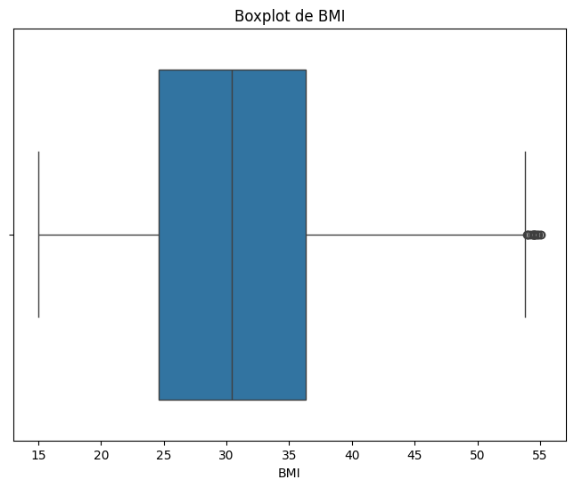

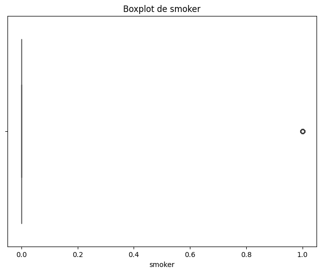

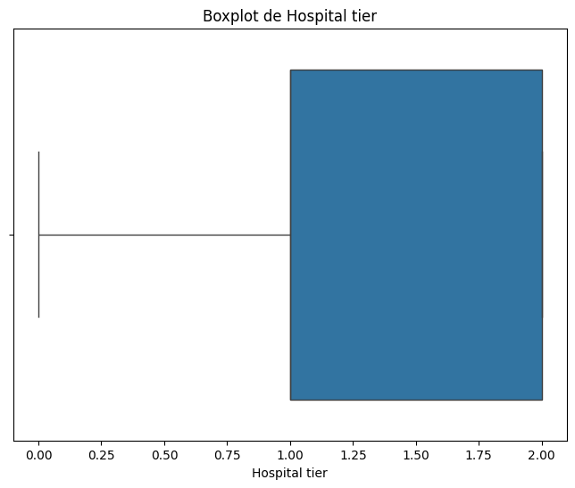

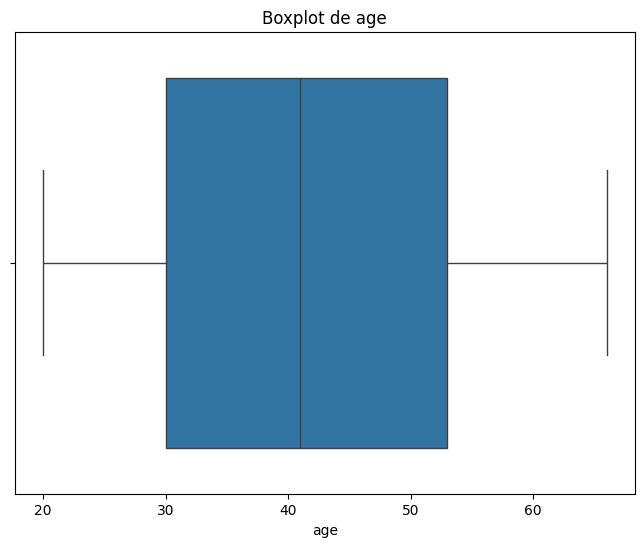

```python
cols = ['BMI','smoker', 'Hospital tier', 'age']

# Loop para plotar os boxplots de cada uma das colunas
for col in cols:
    plt.figure(figsize=(8, 6))  # Ajusta o tamanho da figura
    sns.boxplot(x=dados[col])
    plt.title(f'Boxplot de {col}')
    plt.show()
```

### **Pipeline de Pré-processamento**

1. **`preprocessor = ColumnTransformer(...)`**: Cria um objeto `ColumnTransformer` para aplicar diferentes transformações nas colunas numéricas e categóricas do conjunto de dados.
2. **Transformadores**:
   - **`('num', StandardScaler(), X.select_dtypes(include=['int64', 'float64']).columns)`**: Aplica a normalização nas colunas numéricas usando `StandardScaler`, que escala os dados para que tenham média 0 e desvio padrão 1.
   - **`('cat', OneHotEncoder(drop='first', handle_unknown='ignore', sparse_output=False), X.select_dtypes(include=['object']).columns)`**: Aplica a codificação "one-hot" nas colunas categóricas, tratando valores desconhecidos com `handle_unknown='ignore'` e retornando uma matriz densa com `sparse_output=False`.

### **Funcionamento**

O `ColumnTransformer` permite aplicar diferentes transformações a diferentes tipos de dados de forma eficiente, como a normalização para dados numéricos e a codificação "one-hot" para dados categóricos.

### **Utilidade**

Essas transformações são essenciais para preparar os dados para modelos de aprendizado de máquina, já que muitos algoritmos requerem dados numéricos escalados ou codificados em formato apropriado.

```python
# Criar pipeline de pré-processamento
preprocessor = ColumnTransformer(
    transformers=[
        ('num', StandardScaler(), X.select_dtypes(include=['int64', 'float64']).columns),
        ('cat', OneHotEncoder(drop='first', handle_unknown='ignore', sparse_output=False), X.select_dtypes(include=['object']).columns)
    ]
)
```

### **# Lista de modelos para avaliação**

1. **Criação da Lista de Modelos para Avaliação**:
   - O código define um dicionário chamado **`modelos`**, onde cada chave é o nome de um modelo de regressão e o valor é a instância do modelo correspondente.
   - **Modelos de Regressão**:
     - **`LinearRegression`**: Modelo de regressão linear simples.
     - **`BayesianRidge`**: Regressão linear com regularização bayesiana.
     - **`ElasticNet`**: Modelo que combina Lasso e Ridge com o parâmetro **`alpha=0.1`** e **`l1_ratio=0.5`**.
     - **`HuberRegressor`**: Regressão robusta a outliers.
     - **`DecisionTreeRegressor`**: Árvore de decisão para regressão.
     - **`RandomForestRegressor`**: Floresta aleatória para regressão com **`n_estimators=100`** árvores.
     - **`GradientBoostingRegressor`**: Modelo de boosting para regressão com **`n_estimators=100`** árvores.
     - **`SVR`**: Máquinas de vetores de suporte para regressão com kernel RBF e parâmetros **`C=100, gamma=0.1, epsilon=0.1`**.
     - **`KNeighborsRegressor`**: Regressão baseada no algoritmo K-vizinhos mais próximos (**`n_neighbors=5`**).
     - **`MLPRegressor`**: Perceptron multicamada para regressão com **`hidden_layer_sizes=(100, 50)`** e **`max_iter=500`**.

### **Funcionamento**

- O código define uma coleção de diferentes modelos de regressão que podem ser utilizados para prever a variável alvo com base nas variáveis preditoras.

### **Utilidade**

Este conjunto de modelos é utilizado para avaliar qual abordagem de regressão melhor se adapta aos dados e fornece as melhores métricas de desempenho, como erro médio absoluto, erro quadrático médio e coeficiente de determinação (**R²**).

```python
# Lista de modelos para avaliação
modelos = {
    "Regressão Linear": LinearRegression(),
    "Bayesian Ridge": BayesianRidge(),
    "ElasticNet": ElasticNet(alpha=0.1, l1_ratio=0.5, random_state=42),
    "Huber Regressor": HuberRegressor(),
    "Decision Tree": DecisionTreeRegressor(random_state=42),
    "Random Forest": RandomForestRegressor(random_state=42, n_estimators=100),
    "Gradient Boosting": GradientBoostingRegressor(random_state=42, n_estimators=100),
    "Support Vector Regression (SVR)": SVR(kernel='rbf', C=100, gamma=0.1, epsilon=0.1),
    "KNN Regressor": KNeighborsRegressor(n_neighbors=5),
    "MLP Regressor": MLPRegressor(hidden_layer_sizes=(100, 50), max_iter=500, random_state=42)
}
```

### **# Avaliar os modelos**

1. **Avaliação dos Modelos**:
   - O código define um loop que avalia vários modelos de regressão, ajustando-os aos dados de treino e calculando diversas métricas de desempenho.
   - **Pipeline de Pré-processamento e Modelo**: Para cada modelo, é criado um pipeline que aplica o pré-processamento de dados (normalização e codificação) antes de treinar o modelo.
   - **Métricas Calculadas**:
     - **RMSE (Root Mean Squared Error)**: Calcula o erro médio quadrático raiz tanto no treino quanto no teste.
     - **MAE (Mean Absolute Error)**: Mede a média dos erros absolutos no conjunto de teste.
     - **R²**: Coeficiente de determinação que indica a qualidade da previsão do modelo.
     - **Correlação de Pearson**: Avalia a relação linear entre os valores reais e previstos.
2. **Gráfico de Previsões vs Valores Reais**:
   - Para cada modelo, um gráfico de dispersão (scatter plot) é gerado comparando os valores reais e previstos. A linha de perfeição é adicionada, indicando onde os valores reais e previstos seriam iguais.

### **Funcionamento**

- O código treina e avalia cada modelo de regressão no conjunto de treino e teste.
- Após o treinamento e a previsão, ele calcula as métricas de desempenho e plota gráficos de dispersão para visualização.
- Cada modelo é avaliado com base nas métricas calculadas, e os resultados são armazenados para comparação posterior.

### **Utilidade**

Este código ajuda a comparar o desempenho de diferentes modelos de regressão em termos de erro (RMSE, MAE) e da capacidade de explicação (R²). Além disso, os gráficos de dispersão auxiliam na visualização da precisão das previsões em relação aos valores reais.

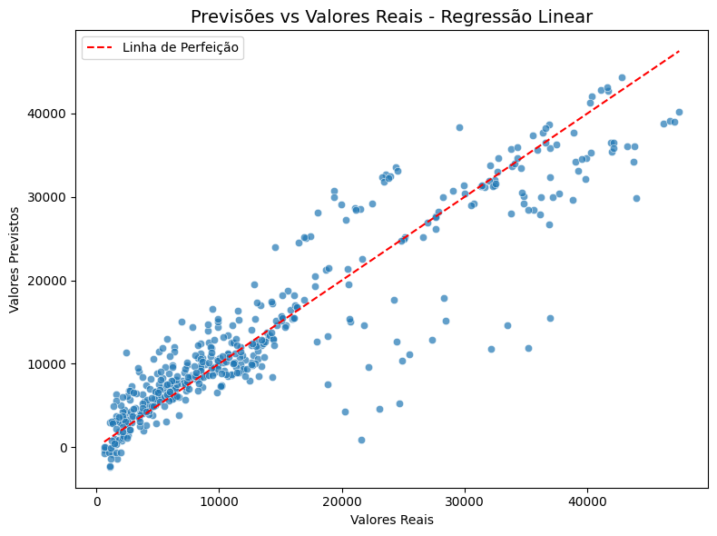

```
Modelo: Regressão Linear
RMSE (Treinamento): 4450.56
RMSE (Teste): 4624.96
MAE (Teste): 2893.73
R² (Teste): 0.85
Correlação: 0.92
```

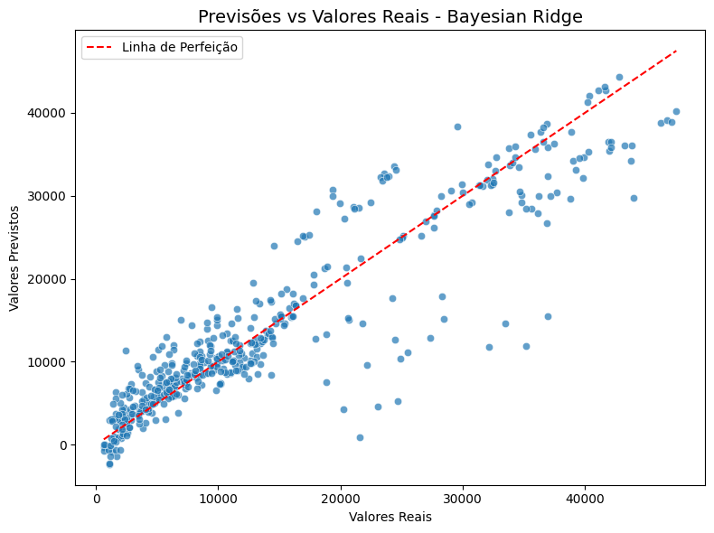

```
Modelo: Bayesian Ridge
RMSE (Treinamento): 4450.56
RMSE (Teste): 4624.89
MAE (Teste): 2894.40
R² (Teste): 0.85
Correlação: 0.92
```

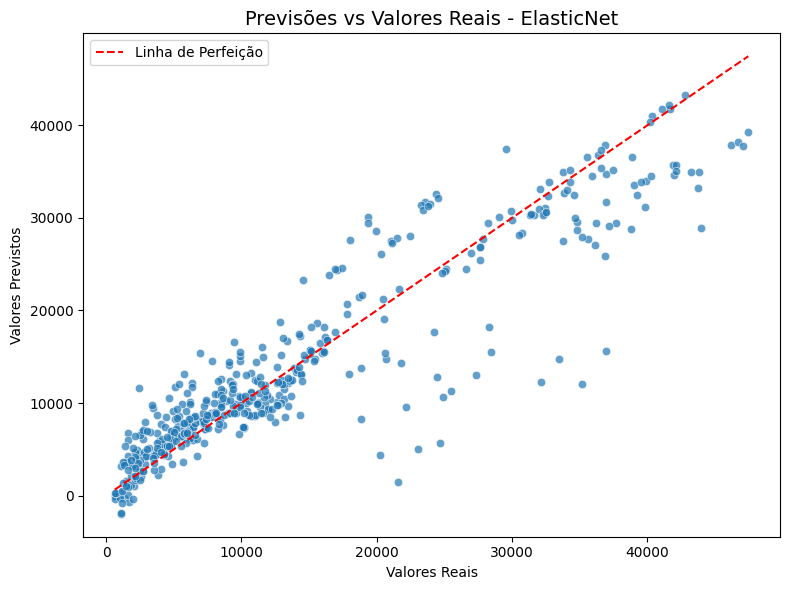

```
Modelo: ElasticNet
RMSE (Treinamento): 4476.69
RMSE (Teste): 4642.59
MAE (Teste): 2982.65
R² (Teste): 0.85
Correlação: 0.92
```

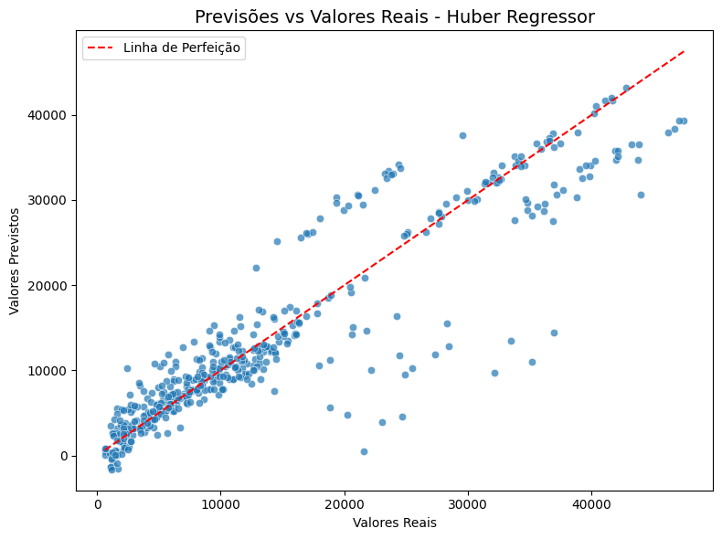

```
Modelo: Huber Regressor
RMSE (Treinamento): 4521.42
RMSE (Teste): 4725.19
MAE (Teste): 2770.28
R² (Teste): 0.84
Correlação: 0.92
```

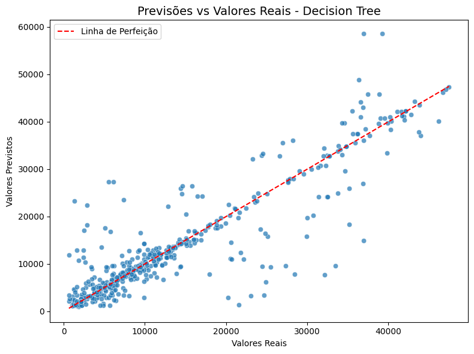

```
Modelo: Decision Tree
RMSE (Treinamento): 425.98
RMSE (Teste): 5468.05
MAE (Teste): 2917.49
R² (Teste): 0.79
Correlação: 0.89
```

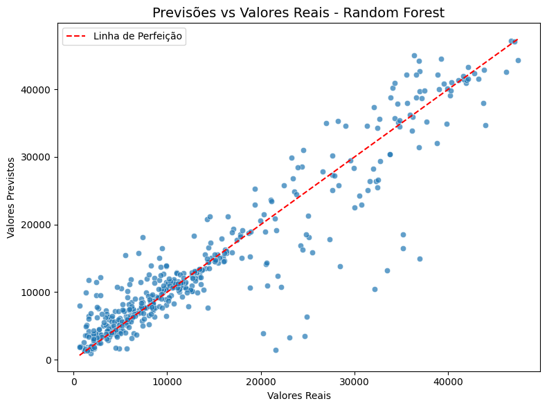

```
Modelo: Random Forest
RMSE (Treinamento): 1536.48
RMSE (Teste): 4287.75
MAE (Teste): 2490.85
R² (Teste): 0.87
Correlação: 0.93
```

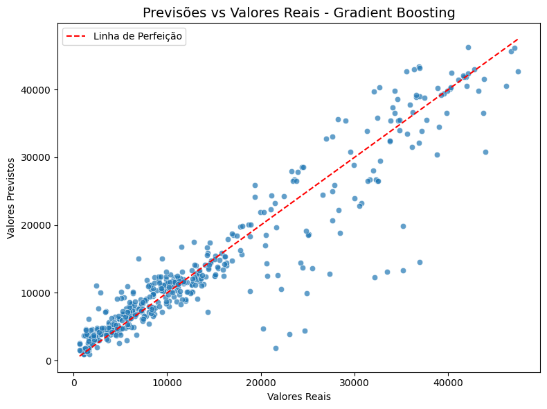

```
Modelo: Gradient Boosting
RMSE (Treinamento): 3251.75
RMSE (Teste): 4100.49
MAE (Teste): 2450.43
R² (Teste): 0.88
Correlação: 0.94
```

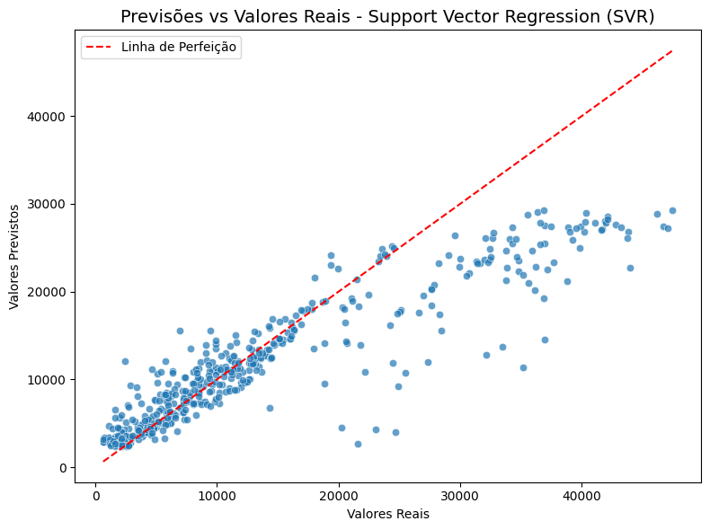

```
Modelo: Support Vector Regression (SVR)
RMSE (Treinamento): 6060.97
RMSE (Teste): 6117.38
MAE (Teste): 3755.84
R² (Teste): 0.73
Correlação: 0.92
```

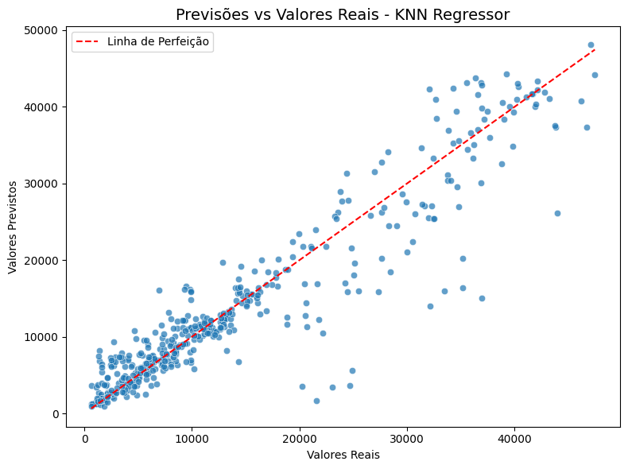

```
Modelo: KNN Regressor
RMSE (Treinamento): 3252.57
RMSE (Teste): 4244.43
MAE (Teste): 2520.65
R² (Teste): 0.87
Correlação: 0.93
```

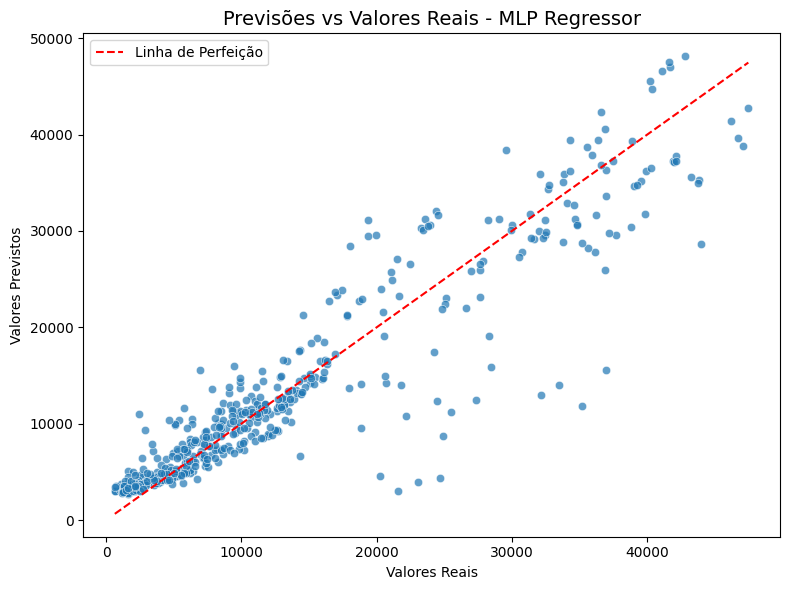

```
Modelo: MLP Regressor
RMSE (Treinamento): 4180.65
RMSE (Teste): 4441.83
MAE (Teste): 2807.23
R² (Teste): 0.86
Correlação: 0.93
```

```python
# Avaliar os modelos
resultados = []

for nome, modelo in modelos.items():
    # Criar pipeline para o modelo
    pipeline = Pipeline(steps=[
        ('preprocessor', preprocessor),
        ('model', modelo)
    ])

    # Treinar o modelo
    pipeline.fit(X_train, y_train)

    # Fazer previsões
    y_pred_train = pipeline.predict(X_train)
    y_pred_test = pipeline.predict(X_test)

    # Avaliar o modelo
    rmse_train = np.sqrt(mean_squared_error(y_train, y_pred_train))
    rmse_test = np.sqrt(mean_squared_error(y_test, y_pred_test))
    mae_test = mean_absolute_error(y_test, y_pred_test)
    r2 = r2_score(y_test, y_pred_test)

    # Calcular a correlação entre os valores reais e previstos no teste
    correlacao = np.corrcoef(y_test, y_pred_test)[0, 1]  # Correlação de Pearson

    # Salvar resultados
    resultados.append({
        "Modelo": nome,
        "RMSE Treino": rmse_train,
        "RMSE Teste": rmse_test,
        "MAE Teste": mae_test,
        "R² Teste": r2,
        "Correlação": correlacao
    })

    # Plotar gráfico de previsões vs. valores reais
    plt.figure(figsize=(8, 6))
    sns.scatterplot(x=y_test, y=y_pred_test, alpha=0.7)
    plt.plot([y_test.min(), y_test.max()], [y_test.min(), y_test.max()], color='red', linestyle='--', label="Linha de Perfeição")
    plt.title(f"Previsões vs Valores Reais - {nome}", fontsize=14)
    plt.xlabel("Valores Reais")
    plt.ylabel("Valores Previstos")
    plt.legend()
    plt.tight_layout()
    plt.show()

    print(f"\nModelo: {nome}")
    print(f"RMSE (Treinamento): {rmse_train:.2f}")
    print(f"RMSE (Teste): {rmse_test:.2f}")
    print(f"MAE (Teste): {mae_test:.2f}")
    print(f"R² (Teste): {r2:.2f}")
    print(f"Correlação: {correlacao:.2f}")
```

### **# Exibir resultados em um DataFrame**

1. **Exibir Resultados em um DataFrame**:
   - **`df_resultados = pd.DataFrame(resultados)`**: Cria um DataFrame a partir da lista de resultados, onde cada item da lista contém as métricas calculadas para um modelo específico.
   - **`print("\nResultados Comparativos:")`**: Exibe um título para indicar que os resultados a seguir são comparativos entre os modelos.
   - **`print(df_resultados)`**: Exibe o DataFrame **`df_resultados`**, que contém as métricas de avaliação (como RMSE, MAE, R² e Correlação) para todos os modelos de regressão avaliados.

### **Funcionamento**

- O código cria um DataFrame que organiza os resultados de cada modelo em linhas e métricas (RMSE, MAE, R² e Correlação) em colunas, proporcionando uma visão estruturada dos resultados.
- Ele então imprime o DataFrame para que você possa visualizar os resultados de todos os modelos de forma clara.

### **Utilidade**

Este comando facilita a visualização dos resultados de comparação entre os modelos, permitindo uma análise rápida e eficiente das métricas de desempenho de cada modelo.

```python
# Exibir resultados em um DataFrame
df_resultados = pd.DataFrame(resultados)
print("\nResultados Comparativos:")
df_resultados
```

```
Resultados Comparativos:
```

|  | Modelo | RMSE Treino | RMSE Teste | MAE Teste | R² Teste | Correlação |
| --- | --- | --- | --- | --- | --- | --- |
| 0 | Regressão Linear | 4450.555284 | 4624.957011 | 2893.726123 | 0.846768 | 0.920277 |
| 1 | Bayesian Ridge | 4450.557310 | 4624.887677 | 2894.398764 | 0.846772 | 0.920279 |
| 2 | ElasticNet | 4476.690997 | 4642.593846 | 2982.652457 | 0.845597 | 0.920334 |
| 3 | Huber Regressor | 4521.423466 | 4725.187670 | 2770.284327 | 0.840054 | 0.917416 |
| 4 | Decision Tree | 425.981595 | 5468.046413 | 2917.485226 | 0.785810 | 0.893917 |
| 5 | Random Forest | 1536.475442 | 4287.752282 | 2490.846493 | 0.868297 | 0.932334 |
| 6 | Gradient Boosting | 3251.752561 | 4100.486953 | 2450.431661 | 0.879550 | 0.938089 |
| 7 | Support Vector Regression (SVR) | 6060.971607 | 6117.377510 | 3755.835801 | 0.731919 | 0.916935 |
| 8 | KNN Regressor | 3252.569224 | 4244.433110 | 2520.650262 | 0.870945 | 0.933639 |
| 9 | MLP Regressor | 4180.652363 | 4441.830306 | 2807.229430 | 0.858662 | 0.926700 |

### **Utilidade**

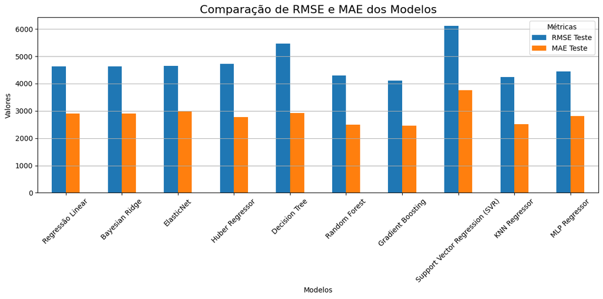

```python
# Visualizar os resultados comparativos
plt.figure(figsize=(12, 8))
df_resultados.set_index("Modelo")[["RMSE Teste", "MAE Teste"]].plot(kind="bar", figsize=(12, 6))
plt.title("Comparação de RMSE e MAE dos Modelos", fontsize=16)
plt.xlabel("Modelos")
plt.ylabel("Valores")
plt.xticks(rotation=45, fontsize=10)
plt.grid(axis='y')
plt.legend(title="Métricas", fontsize=10)
plt.tight_layout()
plt.show()
```

### **Resultados dos Modelos de Regressão**

A tabela abaixo apresenta o desempenho de diferentes modelos de regressão, avaliados com base nas métricas RMSE (Root Mean Squared Error), MAE (Mean Absolute Error), R² (Coeficiente de Determinação) e Correlação. O objetivo é avaliar a precisão de cada modelo na previsão dos custos médicos (charges) de acordo com as características dos pacientes.

| Modelo | RMSE Treino | RMSE Teste | MAE Teste | R² Teste | Correlação |
| --- | --- | --- | --- | --- | --- |
| **Regressão Linear** | 4450.56 | 4624.96 | 2893.73 | 0.8468 | 0.9203 |
| **Bayesian Ridge** | 4450.56 | 4624.89 | 2894.40 | 0.8468 | 0.9203 |
| **ElasticNet** | 4476.69 | 4642.59 | 2982.65 | 0.8456 | 0.9203 |
| **Huber Regressor** | 4521.42 | 4725.19 | 2770.28 | 0.8401 | 0.9174 |
| **Decision Tree** | 425.98 | 5468.05 | 2917.49 | 0.7858 | 0.8939 |
| **Random Forest** | 1536.48 | 4287.75 | 2490.85 | 0.8683 | 0.9323 |
| **Gradient Boosting** | 3251.75 | 4100.49 | 2450.43 | 0.8796 | 0.9381 |
| **Support Vector Regression (SVR)** | 6060.97 | 6117.38 | 3755.84 | 0.7319 | 0.9169 |
| **KNN Regressor** | 3252.57 | 4244.43 | 2520.65 | 0.8709 | 0.9336 |
| **MLP Regressor** | 4180.65 | 4441.83 | 2807.23 | 0.8587 | 0.9267 |

#### **Análise dos Resultados**

- **Modelos com Melhor Performance**: O modelo **Gradient Boosting** teve o melhor desempenho em termos de RMSE, R² e correlação, sendo mais preciso na previsão dos custos médicos.
- **Desempenho do KNN e Random Forest**: Modelos como **KNN Regressor** e **Random Forest** também apresentaram resultados próximos, com valores de R² e correlação elevados, indicando boa capacidade de generalização.
- **Modelo de Árvore de Decisão**: O **Decision Tree** apresentou um erro muito baixo no treinamento (RMSE Treino de 425.98), mas teve uma performance inferior no teste, com RMSE Teste de 5468.05, sugerindo overfitting.